# Assignment 2: Spatial Analysis and Visualization

Healthcare Access and Equity in Pennsylvania

Author

Jed Chew

Published

October 20, 2025

## Assignment Overview

**Learning Objectives:**

- Apply spatial operations to answer policy-relevant research questions
- Integrate census demographic data with spatial analysis
- Create publication-quality visualizations and maps
- Work with spatial data from multiple sources
- Communicate findings effectively for policy audiences

## Part 1: Healthcare Access for Vulnerable Populations

### Research Question

**Which Pennsylvania counties have the highest proportion of vulnerable populations (elderly + low-income) living far from hospitals?**

Your analysis should identify counties that should be priorities for healthcare investment and policy intervention.

### Required Analysis Steps

Complete the following analysis, documenting each step with code and brief explanations:

#### Step 1: Data Collection (5 points)

Load the required spatial data:

- Pennsylvania county boundaries (from lecture data)
- Pennsylvania hospitals (from lecture data)
- Pennsylvania census tracts

**Your Task:**

```r
# Load spatial data
pa_counties <- st_read("data/Pennsylvania_County_Boundaries.shp")
districts <- st_read("data/districts.geojson")
hospitals <- st_read("data/hospitals.geojson")
census_tracts <- tracts(state = "PA", cb = TRUE, progress = FALSE)
metro_areas <- core_based_statistical_areas(cb = TRUE, progress = FALSE)

# Standardize CRS
hospitals <- st_transform(hospitals, st_crs(pa_counties))
census_tracts <- st_transform(census_tracts, st_crs(pa_counties))
metro_areas <- st_transform(metro_areas, st_crs(pa_counties))
districts <- st_transform(districts, st_crs(census_tracts))
```

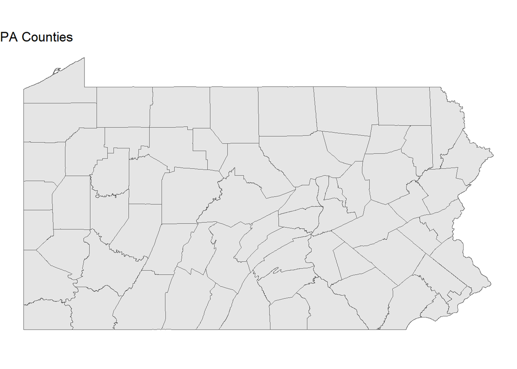

```r
# Check that all data loaded correctly
ggplot(pa_counties) +
  geom_sf() +
  labs(title = "PA Counties") +
  theme_void()
```

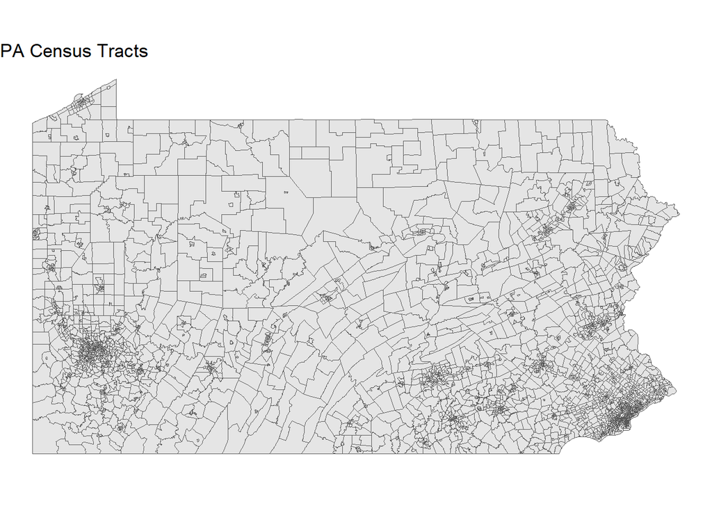

```r
ggplot(census_tracts) +
  geom_sf() +
  labs(title = "PA Census Tracts") +
  theme_void()
```

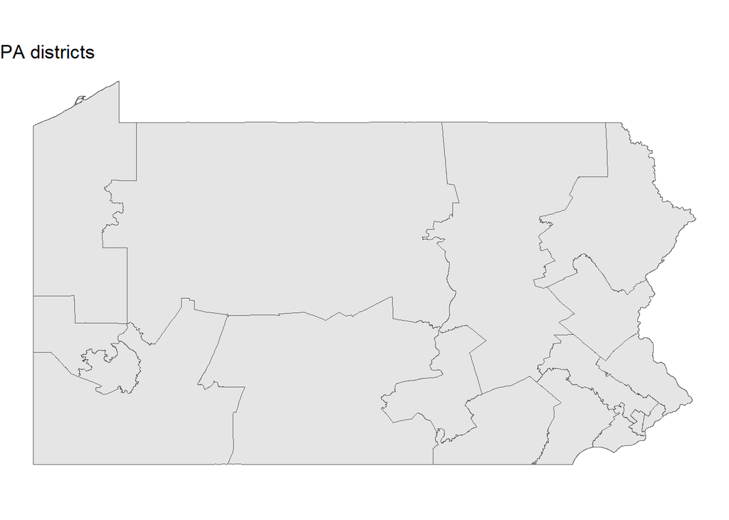

```r
ggplot(districts) +
  geom_sf() +
  labs(title = "PA districts") +
  theme_void()
```

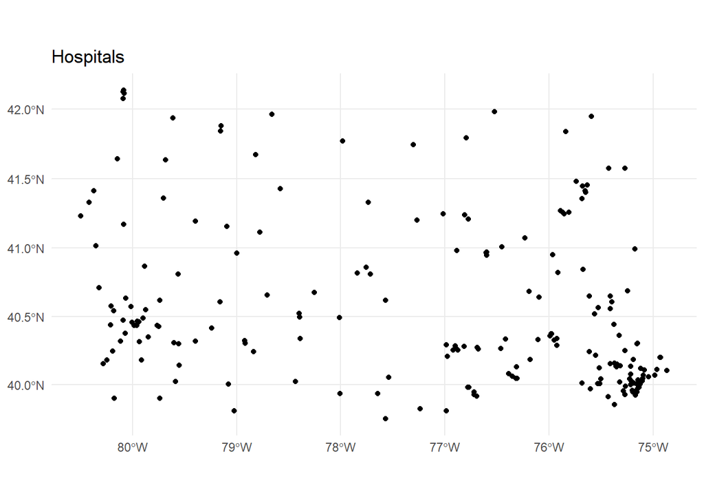

```r
ggplot(hospitals) +
  geom_sf() +
  labs(title = "Hospitals") +
  theme_minimal()
```

**Questions to answer:**

- How many hospitals are in your dataset? – **223 hospitals**

```r
glimpse(hospitals)
```

```
Rows: 223
Columns: 12
$ CHIEF_EXEC <chr> "Peter J Adamo", "Autumn DeShields", "Shawn Parekh", "DIANE…
$ CHIEF_EX_1 <chr> "President", "Chief Executive Officer", "Chief Executive Of…
$ FACILITY_U <chr> "https://www.phhealthcare.org", "https://www.malvernbh.com"…
$ LONGITUDE  <dbl> -79.91131, -75.17005, -75.20963, -80.27907, -79.02513, -75.…
$ COUNTY     <chr> "Washington", "Philadelphia", "Philadelphia", "Washington",…
$ FACILITY_N <chr> "Penn Highlands Mon Valley", "MALVERN BEHAVIORAL HEALTH", "…
$ STREET     <chr> "1163 Country Club Road", "1930 South Broad Street Unit 4",…
$ CITY_OR_BO <chr> "Monongahela", "Philadelphia", "Philadelphia", "WASHINGTON"…
$ LATITUDE   <dbl> 40.18193, 39.92619, 40.02869, 40.15655, 39.80913, 40.24273,…
$ TELEPHONE_ <chr> "724-258-1000", "610-480-8919", "215-483-9900", "7248840710…
$ ZIP_CODE   <chr> "15063", "19145", "19128", "15301", "15552", "19464", "1776…
$ geometry   <POINT [m]> POINT (-8895686 4892415), POINT (-8367892 4855223), P…
```

- How many census tracts? – **3445 census tracts**

```r
glimpse(census_tracts)
```

```
Rows: 3,445
Columns: 14
$ STATEFP    <chr> "42", "42", "42", "42", "42", "42", "42", "42", "42", "42",…
$ COUNTYFP   <chr> "001", "013", "013", "013", "013", "011", "011", "011", "01…
$ TRACTCE    <chr> "031101", "100400", "100500", "100800", "101900", "011200",…
$ GEOIDFQ    <chr> "1400000US42001031101", "1400000US42013100400", "1400000US4…
$ GEOID      <chr> "42001031101", "42013100400", "42013100500", "42013100800",…
$ NAME       <chr> "311.01", "1004", "1005", "1008", "1019", "112", "2", "115"…
$ NAMELSAD   <chr> "Census Tract 311.01", "Census Tract 1004", "Census Tract 1…
$ STUSPS     <chr> "PA", "PA", "PA", "PA", "PA", "PA", "PA", "PA", "PA", "PA",…
$ NAMELSADCO <chr> "Adams County", "Blair County", "Blair County", "Blair Coun…
$ STATE_NAME <chr> "Pennsylvania", "Pennsylvania", "Pennsylvania", "Pennsylvan…
$ LSAD       <chr> "CT", "CT", "CT", "CT", "CT", "CT", "CT", "CT", "CT", "CT",…
$ ALAND      <dbl> 3043185, 993724, 1130204, 996553, 573726, 1539365, 1949529,…
$ AWATER     <dbl> 0, 0, 0, 0, 0, 9308, 159015, 12469, 0, 0, 0, 1271, 6352, 74…
$ geometry   <MULTIPOLYGON [m]> MULTIPOLYGON (((-8575060 48..., MULTIPOLYGON (…
```

- What coordinate reference system is each dataset in? – **all datasets have been projected to WGS 84 / Psuedo-Mercator**

```r
st_crs(hospitals)$Name
```

```
[1] "WGS 84 / Pseudo-Mercator"
```

```r
st_crs(census_tracts)$Name
```

```
[1] "WGS 84 / Pseudo-Mercator"
```

#### Step 2: Get Demographic Data

Use `tidycensus` to download tract-level demographic data for Pennsylvania.

**Required variables:** - Total population - Median household income - Population 65 years and over (you may need to sum multiple age categories)

**Your Task:**

```r
# Load all available variables for ACS 5-year 2022
acs_vars_2022 <- load_variables(2022, "acs5", cache = TRUE)
```

```r
# Helper Variable for Summing Population Values for Elderly Population
elderly_pop = c("B01001_020", "B01001_021", "B01001_022", "B01001_023",
                "B01001_024", "B01001_025",
                "B01001_044", "B01001_045", "B01001_046",
                "B01001_047", "B01001_048", "B01001_049")

# Get tract-level demographic data from ACS
pa_data <- get_acs(
  geography = "tract",
  variables = c(
    total_pop = "B01003_001",
    median_income = "B19013_001",
    elderly_pop = elderly_pop
  ),
  state = "PA",
  year = 2022,
  survey = "acs5",
  output = "wide"
)

# Clean the county names to remove state name and "County"
pa_clean <- pa_data |>
  separate(
    NAME,
    into = c("tract_name", "county_name", "state_name"),
    sep = "; "
  ) |>
  mutate(
    tract_name = str_remove(tract_name, "Census Tract "),
    county_name = str_remove(county_name, " County")
  )
head(pa_clean)
```

```
# A tibble: 6 × 32
  GEOID   tract_name county_name state_name total_popE total_popM median_incomeE
  <chr>   <chr>      <chr>       <chr>           <dbl>      <dbl>          <dbl>
1 420010… 301.01     Adams       Pennsylva…       2658         14          80231
2 420010… 301.03     Adams       Pennsylva…       2416        329         111603
3 420010… 301.04     Adams       Pennsylva…       3395        332          81150
4 420010… 302        Adams       Pennsylva…       5475        464          68363
5 420010… 303        Adams       Pennsylva…       4412        215          81577
6 420010… 304        Adams       Pennsylva…       5462        206          88558
# ℹ 25 more variables: median_incomeM <dbl>, elderly_pop1E <dbl>,
#   elderly_pop1M <dbl>, elderly_pop2E <dbl>, elderly_pop2M <dbl>,
#   elderly_pop3E <dbl>, elderly_pop3M <dbl>, elderly_pop4E <dbl>,
#   elderly_pop4M <dbl>, elderly_pop5E <dbl>, elderly_pop5M <dbl>,
#   elderly_pop6E <dbl>, elderly_pop6M <dbl>, elderly_pop7E <dbl>,
#   elderly_pop7M <dbl>, elderly_pop8E <dbl>, elderly_pop8M <dbl>,
#   elderly_pop9E <dbl>, elderly_pop9M <dbl>, elderly_pop10E <dbl>, …
```

```r
# Sum elderly population
pa_summary <- pa_clean |>
  mutate(
    elderly_popE = rowSums(across(matches("^elderly_pop\\d+E$")), na.rm = TRUE),
    # for MOE, ACS guidance is to combine by quadrature
    elderly_popM = sqrt(rowSums(across(matches("^elderly_pop\\d+M$"))^2, na.rm =
                                  TRUE)),
    pct_elderly = elderly_popE / total_popE
  ) |>
  select(GEOID, tract_name, county_name, total_popE, median_incomeE, elderly_popE,
         elderly_popM, pct_elderly)
head(pa_summary)
```

```
# A tibble: 6 × 8
  GEOID       tract_name county_name total_popE median_incomeE elderly_popE
  <chr>       <chr>      <chr>            <dbl>          <dbl>        <dbl>
1 42001030101 301.01     Adams             2658          80231          521
2 42001030103 301.03     Adams             2416         111603          467
3 42001030104 301.04     Adams             3395          81150          730
4 42001030200 302        Adams             5475          68363         1020
5 42001030300 303        Adams             4412          81577          722
6 42001030400 304        Adams             5462          88558         1206
# ℹ 2 more variables: elderly_popM <dbl>, pct_elderly <dbl>
```

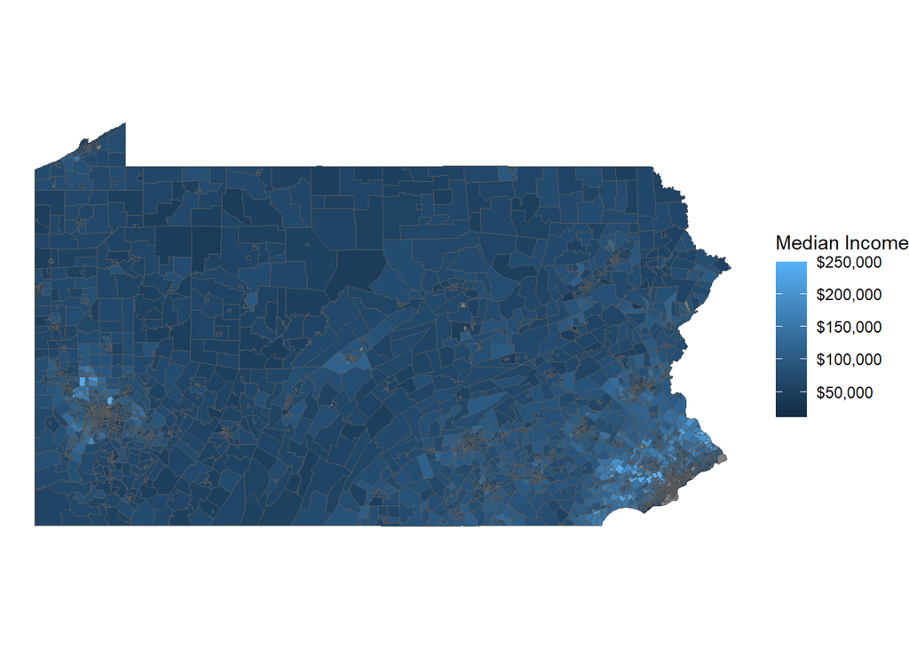

```r
# Join to tract boundaries
tracts_with_data <- census_tracts |>
  left_join(pa_summary, by = "GEOID")

# Map to confirm
ggplot(tracts_with_data) +
  geom_sf(aes(fill = median_incomeE), linewidth = 0) +
  scale_fill_continuous(labels = label_dollar()) +
  labs(fill = "Median Income") +
  theme_void()
```

**Questions to answer:**

- What year of ACS data are you using? – **2022 5-Year Estimates**
- How many tracts have missing income data? – **63**
- What is the median income across all PA census tracts? – **$70,188**

```r
pa_tract_income_qns <- pa_summary |>
  summarize(
    tracts_missing_income = sum(is.na(median_incomeE)),
    tracts_median_income = median(median_incomeE, na.rm = TRUE),
    tract_median_elderly = mean(pct_elderly, na.rm = TRUE)
  )
pa_tract_income_qns
```

```
# A tibble: 1 × 3
  tracts_missing_income tracts_median_income tract_median_elderly
                  <int>                <dbl>                <dbl>
1                    63                70188                0.190
```

#### Step 3: Define Vulnerable Populations

Identify census tracts with vulnerable populations based on TWO criteria:

1. Low median household income (choose an appropriate threshold) – **$70,000**
2. Significant elderly population (choose an appropriate threshold) – **25%**

**Your Task:**

```r
# Filter for vulnerable tracts based on your criteria
pa_vulnerable <- pa_summary |>
  filter(median_incomeE <= 70000 & pct_elderly >= 0.25)
pa_vulnerable
```

```
# A tibble: 293 × 8
   GEOID       tract_name county_name total_popE median_incomeE elderly_popE
   <chr>       <chr>      <chr>            <dbl>          <dbl>        <dbl>
 1 42001030902 309.02     Adams             4181          69855         1532
 2 42003040400 404        Allegheny         1629          60329          705
 3 42003100500 1005       Allegheny         2023          62411          536
 4 42003130700 1307       Allegheny         2068          30518          537
 5 42003270100 2701       Allegheny         2459          61481          633
 6 42003320400 3204       Allegheny         1846          66691          465
 7 42003416000 4160       Allegheny         1475          58654          394
 8 42003417100 4171       Allegheny         2131          68284          536
 9 42003420000 4200       Allegheny         1532          43333          460
10 42003427200 4272       Allegheny         4544          56912         1163
# ℹ 283 more rows
# ℹ 2 more variables: elderly_popM <dbl>, pct_elderly <dbl>
```

**Questions to answer:**

- What income threshold did you choose and why? - **$70,000. This threshold is slightly below median income across all PA census tracts of $70,188**
- What elderly population threshold did you choose and why? - **25%. This threshold is slightly higher than the mean percentage elderly population across all PA census tracts of 19.0%**
- How many tracts meet your vulnerability criteria? - **293 tracts**
- What percentage of PA census tracts are considered vulnerable by your definition? = **8.5% are considered vulnerable**

```r
# Percentage of PA census tracts considered vulnerable
293 / 3445
```

```
[1] 0.0850508
```

#### Step 4: Calculate Distance to Hospitals

For each vulnerable tract, calculate the distance to the nearest hospital.

**Your Task:**

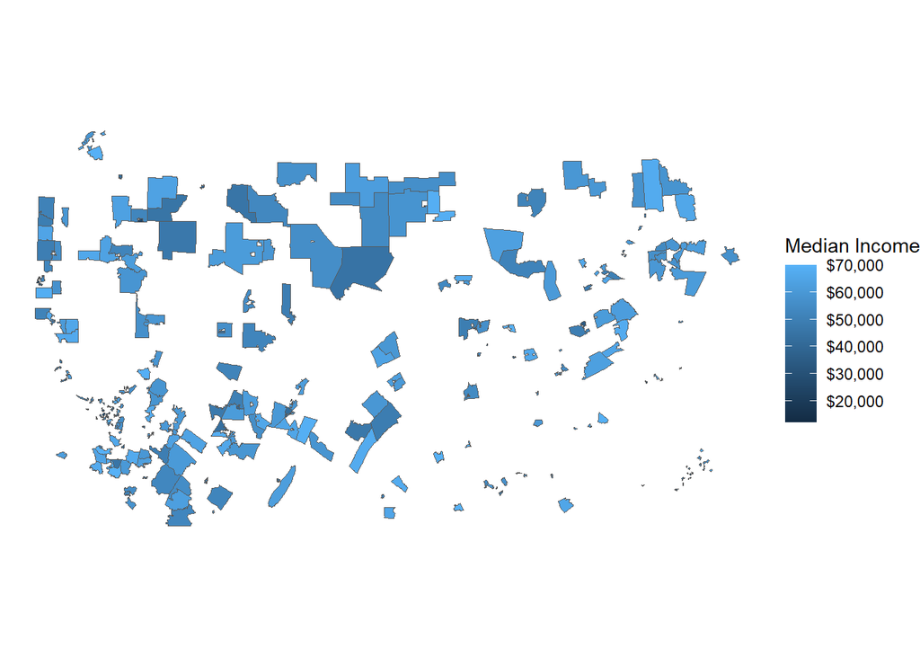

```r
# Update Median Income Map from Step 2
vulnerable_tracts <- tracts_with_data |>
  filter(median_incomeE <= 70000, pct_elderly >= 0.25)

# Project to Accurate Projected CRS of NAD 83 / Pennsylvania South State Plane
pa_crs <- 32129
vul_proj <- st_transform(vulnerable_tracts, pa_crs)
hosp_proj   <- st_transform(hospitals, pa_crs)

# Map to confirm
ggplot(vul_proj) +
  geom_sf(aes(fill = median_incomeE), linewidth = 0) +
  scale_fill_continuous(labels = label_dollar()) +
  labs(fill = "Median Income") +
  theme_void()
```

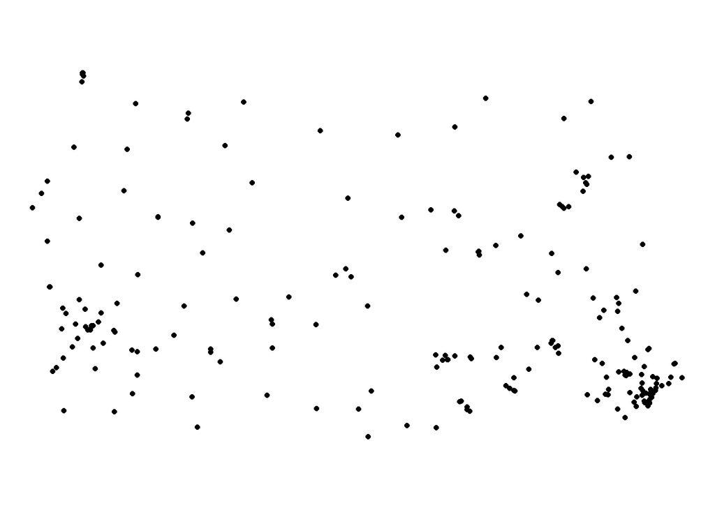

```r
ggplot(hosp_proj) +
  geom_sf() +
  theme_void()
```

```r
# Calculate distance from each centroid to nearest hospital, then convert to miles
centroids <- st_centroid(vul_proj, of_largest_polygon = TRUE)
nn_idx    <- st_nearest_feature(centroids, hosp_proj)
dist_m    <- st_distance(centroids, hosp_proj[nn_idx, ], by_element = TRUE)

vul_proj$dist_nearest_hosp_mi <- set_units(dist_m, "mi") |> drop_units()

vul_proj |>
  st_drop_geometry() |>
  select(GEOID, tract_name, county_name, dist_nearest_hosp_mi) |>
  arrange(desc(dist_nearest_hosp_mi)) |>
  head(10)
```

```
         GEOID tract_name county_name dist_nearest_hosp_mi
1  42103950104    9501.04        Pike             29.11594
2  42113960201    9602.01    Sullivan             19.85868
3  42023960200       9602     Cameron             19.46556
4  42043025300        253     Dauphin             19.15826
5  42127960100       9601       Wayne             18.32885
6  42053530200       5302      Forest             18.13084
7  42061951100       9511  Huntingdon             17.71162
8  42103950902    9509.02        Pike             17.52023
9  42033330600       3306  Clearfield             17.29267
10 42105950500       9505      Potter             17.12490
```

**Requirements:**

- Use an appropriate projected coordinate system for Pennsylvania
- Calculate distances in miles
- Explain why you chose your projection

**Questions to answer:**

- What is the average distance to the nearest hospital for vulnerable tracts? – **5.70 miles**
- What is the maximum distance? – **29.1 miles**

```r
pa_vul_tract_qns <- vul_proj |>
  st_drop_geometry() |>
  summarize(
    average_distance = mean(dist_nearest_hosp_mi, na.rm = TRUE),
    max_distance = max(dist_nearest_hosp_mi),
  )
pa_vul_tract_qns
```

```
  average_distance max_distance
1         5.699299     29.11594
```

- How many vulnerable tracts are more than 15 miles from the nearest hospital? – **17 vulnerable tracts**

```r
pa_num_vul_qns <- vul_proj |>
  st_drop_geometry() |>
  filter(dist_nearest_hosp_mi > 15)
pa_num_vul_qns
```

```
   STATEFP COUNTYFP TRACTCE              GEOIDFQ       GEOID    NAME
1       42      023  960200 1400000US42023960200 42023960200    9602
2       42      067  070201 1400000US42067070201 42067070201  702.01
3       42      071  014601 1400000US42071014601 42071014601  146.01
4       42      113  960201 1400000US42113960201 42113960201 9602.01
5       42      061  951100 1400000US42061951100 42061951100    9511
6       42      043  025300 1400000US42043025300 42043025300     253
7       42      127  960100 1400000US42127960100 42127960100    9601
8       42      015  950900 1400000US42015950900 42015950900    9509
9       42      039  110400 1400000US42039110400 42039110400    1104
10      42      103  950104 1400000US42103950104 42103950104 9501.04
11      42      103  950902 1400000US42103950902 42103950902 9509.02
12      42      111  021903 1400000US42111021903 42111021903  219.03
13      42      105  950500 1400000US42105950500 42105950500    9505
14      42      113  960202 1400000US42113960202 42113960202 9602.02
```

[output cut: 57 more lines]

#### Step 5: Identify Underserved Areas

Define “underserved” as vulnerable tracts that are more than 15 miles from the nearest hospital.

**Questions to answer:**

- How many tracts are underserved? – **17 tracts (same as last question of Step 4)**
- What percentage of vulnerable tracts are underserved? – **5.8% of vulnerable tracts are underserved**

```r
17 / 293
```

```
[1] 0.05802048
```

- Does this surprise you? Why or why not? – **This low percentage does not surprise me, given that Pennsylvania is home to the hospital system of Penn Medicine and the Children’s Hospital of Philadelphia (CHOP).**

#### Step 6: Aggregate to County Level

Use spatial joins and aggregation to calculate county-level statistics about vulnerable populations and hospital access.

**Your Task:**

```r
# Normalize the county layer (create county_geoid + county_name)
pa_counties_norm <- pa_counties |>
  mutate(
    county_geoid = paste0("42", str_pad(as.character(FIPS_COUNT), 3, pad = "0")),
    county_name  = COUNTY_NAM
  ) |>
  st_transform(32129) |>                     # PA South State Plane (meters)
  select(county_geoid, county_name, geometry)

# Define underserved threshold
underserved_threshold_mi <- 15

# Spatial join tracts → counties and aggregate
county_summary <- pa_counties_norm |>
  st_join(
    vul_proj |>
      mutate(underserved = dist_nearest_hosp_mi > underserved_threshold_mi) |>
      select(tr_geoid = GEOID,
             dist_nearest_hosp_mi,
             total_popE,
             elderly_popE,
             underserved),
    join = st_intersects,
    left = TRUE                                  # keep all 67 counties
  ) %>%
  st_drop_geometry() |>
  group_by(county_geoid, county_name) |>
  summarise(
    n_vulnerable_tracts        = sum(!is.na(tr_geoid)),
    n_underserved_tracts       = sum(underserved %in% TRUE, na.rm = TRUE),
    pct_vuln_underserved       = 100 * n_underserved_tracts / n_vulnerable_tracts,
    avg_dist_nearest_hosp_mi   = mean(dist_nearest_hosp_mi, na.rm = TRUE),
    total_vulnerable_residents = sum(replace_na(total_popE, 0), na.rm = TRUE),
  ) |>
ungroup() |>
arrange(desc(pct_vuln_underserved))

county_summary
```

```
# A tibble: 67 × 7
   county_geoid county_name n_vulnerable_tracts n_underserved_tracts
   <chr>        <chr>                     <int>                <int>
 1 42043        DAUPHIN                       1                    1
 2 42099        PERRY                         2                    2
 3 42015        BRADFORD                      3                    2
 4 42035        CLINTON                       3                    2
 5 42113        SULLIVAN                      3                    2
 6 42023        CAMERON                       2                    1
 7 42057        FULTON                        2                    1
 8 42067        JUNIATA                       4                    2
 9 42033        CLEARFIELD                    5                    2
10 42055        FRANKLIN                      5                    2
# ℹ 57 more rows
# ℹ 3 more variables: pct_vuln_underserved <dbl>,
#   avg_dist_nearest_hosp_mi <dbl>, total_vulnerable_residents <dbl>
```

**Required county-level statistics:** - Number of vulnerable tracts - Number of underserved tracts  
- Percentage of vulnerable tracts that are underserved - Average distance to nearest hospital for vulnerable tracts - Total vulnerable population

**Questions to answer:**

- Which 5 counties have the highest percentage of underserved vulnerable tracts? – **Dauphin, Perry, Bradford, Clinton, Sullivan**

```r
slice(county_summary, 1:5)
```

```
# A tibble: 5 × 7
  county_geoid county_name n_vulnerable_tracts n_underserved_tracts
  <chr>        <chr>                     <int>                <int>
1 42043        DAUPHIN                       1                    1
2 42099        PERRY                         2                    2
3 42015        BRADFORD                      3                    2
4 42035        CLINTON                       3                    2
5 42113        SULLIVAN                      3                    2
# ℹ 3 more variables: pct_vuln_underserved <dbl>,
#   avg_dist_nearest_hosp_mi <dbl>, total_vulnerable_residents <dbl>
```

- Which counties have the most vulnerable people living far from hospitals? **– Pike, Bradford, Forest, Sullivan, Perry, Fulton, and Dauphin**

```r
county_summary |>
  filter(avg_dist_nearest_hosp_mi > 15) |>
  arrange(desc(total_vulnerable_residents))
```

```
# A tibble: 7 × 7
  county_geoid county_name n_vulnerable_tracts n_underserved_tracts
  <chr>        <chr>                     <int>                <int>
1 42103        PIKE                          8                    3
2 42015        BRADFORD                      3                    2
3 42053        FOREST                        3                    1
4 42113        SULLIVAN                      3                    2
5 42099        PERRY                         2                    2
6 42057        FULTON                        2                    1
7 42043        DAUPHIN                       1                    1
# ℹ 3 more variables: pct_vuln_underserved <dbl>,
#   avg_dist_nearest_hosp_mi <dbl>, total_vulnerable_residents <dbl>
```

- Are there any patterns in where underserved counties are located?

#### Step 7: Create Summary Table

Create a professional table showing the top 10 priority counties for healthcare investment.

**Your Task:**

```r
priority_counties <- county_summary |>
  arrange(desc(avg_dist_nearest_hosp_mi), desc(total_vulnerable_residents)) |>
  select(county_name, total_vulnerable_residents, n_vulnerable_tracts,
         n_underserved_tracts, avg_dist_nearest_hosp_mi) |>
  slice(1:10)

kable(priority_counties,
      col.names = c("County", "Vulnerable Residents", "Vulnerable Tracts",
                    "Underserved Tracts", "Avg Distance to Nearest Hospital"),
      caption = "Top 10 Priority Counties in PA for Healthcare Investment",
      format.args = list(big.mark = ","))
```

Top 10 Priority Counties in PA for Healthcare Investment

| County | Vulnerable Residents | Vulnerable Tracts | Underserved Tracts | Avg Distance to Nearest Hospital |
| --- | --- | --- | --- | --- |
| DAUPHIN | 4,018 | 1 | 1 | 19.15826 |
| PERRY | 5,800 | 2 | 2 | 17.53304 |
| SULLIVAN | 6,079 | 3 | 2 | 16.30149 |
| BRADFORD | 9,936 | 3 | 2 | 16.18085 |
| FULTON | 4,067 | 2 | 1 | 15.95926 |
| PIKE | 14,125 | 8 | 3 | 15.64696 |
| FOREST | 7,335 | 3 | 1 | 15.04744 |
| COLUMBIA | 7,645 | 3 | 1 | 14.13191 |
| CLINTON | 7,672 | 3 | 2 | 13.84024 |
| CLARION | 11,616 | 4 | 1 | 13.04375 |

**Requirements:**

- Use `knitr::kable()` or similar for formatting
- Include descriptive column names
- Format numbers appropriately (commas for population, percentages, etc.)
- Add an informative caption
- Sort by priority (you decide the metric)

## Part 2: Comprehensive Visualization

Using the skills from Week 3 (Data Visualization), create publication-quality maps and charts.

### Map 1: County-Level Choropleth

Create a choropleth map showing healthcare access challenges at the county level.

**Your Task:**

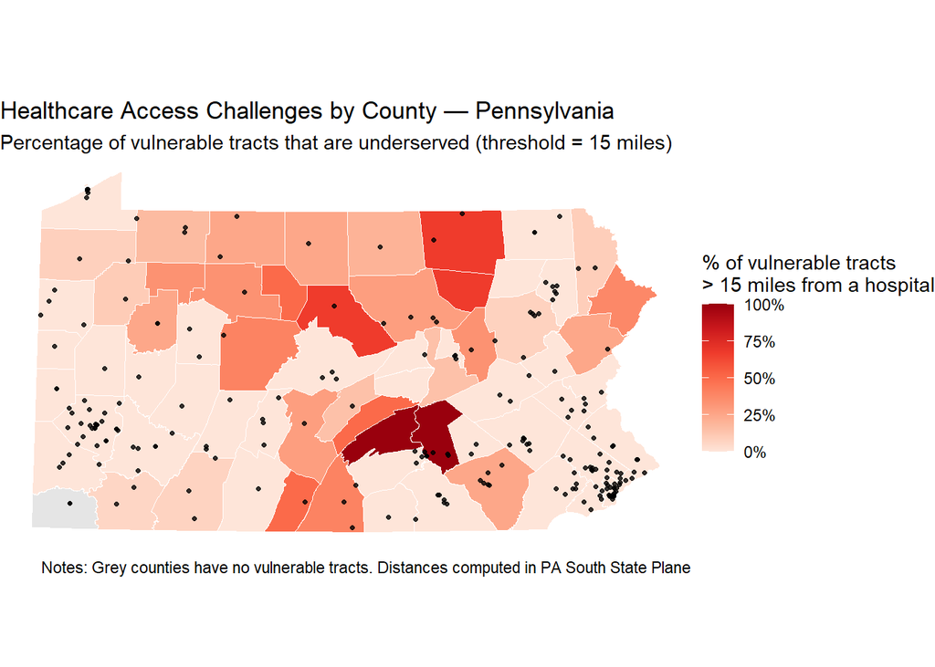

```r
library(scales)
library(RColorBrewer)

# Spatial Joins and Projections
county_summary_sf <- pa_counties_norm %>%
  left_join(county_summary, by = "county_geoid")
hosp_pts <- hospitals %>% st_transform(st_crs(county_summary_sf))

# Create county-level access map
ggplot(county_summary_sf) +
  geom_sf(aes(fill = pct_vuln_underserved), color = "white", linewidth = 0.25) +
  geom_sf(data = hosp_pts, size = 0.9, alpha = 0.8) +
  scale_fill_distiller(
    name = "% of vulnerable tracts\n> 15 miles from a hospital",
    palette = "Reds",
    direction = 1,          # light (low) -> dark (high)
    na.value = "grey90",
    limits = c(0, 100),
    breaks = c(0, 25, 50, 75, 100),
    labels = label_percent(accuracy = 1, scale = 1),
    guide = guide_colorbar(barheight = unit(80, "pt"))
  ) +
  labs(
    title = "Healthcare Access Challenges by County — Pennsylvania",
    subtitle = "Percentage of vulnerable tracts that are underserved (threshold = 15 miles)",
    caption  = "Notes: Grey counties have no vulnerable tracts. Distances computed in PA South State Plane"
  ) +
  theme_void() +
  theme(legend.position = "right")
```

**Requirements:** - Fill counties by percentage of vulnerable tracts that are underserved - Include hospital locations as points - Use an appropriate color scheme - Include clear title, subtitle, and caption - Use `theme_void()` or similar clean theme - Add a legend with formatted labels

### Map 2: Detailed Vulnerability Map

Create a map highlighting underserved vulnerable tracts.

**Your Task:**

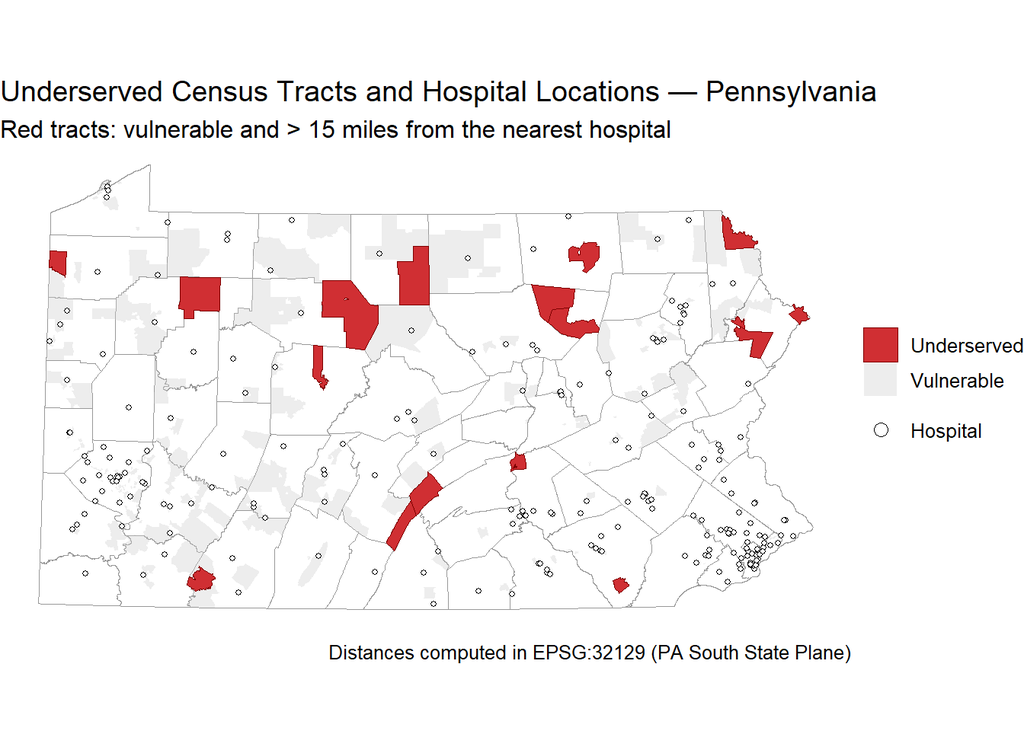

```r
# Create detailed tract-level map
underserved_threshold_mi <- 15
vul_status <- vul_proj |>
  mutate(
    status = if_else(dist_nearest_hosp_mi > underserved_threshold_mi,
                     "Underserved", "Vulnerable")
  )

# 2) Plot
ggplot() +
  # Base: county boundaries for context (low visual weight)
  geom_sf(data = pa_counties_norm, fill = NA, color = "grey60", linewidth = 0.3) +

  # Other vulnerable tracts (de-emphasized)
  geom_sf(data = subset(vul_status, status == "Vulnerable"),
          aes(fill = status), color = NA, alpha = 0.35) +

  # Underserved vulnerable tracts (primary focus)
  geom_sf(data = subset(vul_status, status == "Underserved"),
          aes(fill = status), color = "#7f0000", linewidth = 0.2, alpha = 0.9) +

  # Hospitals (symbols on top for maximum legibility)
  geom_sf(data = hosp_pts, aes(shape = "Hospital"),
          size = 1.2, color = "black", fill = "white", stroke = 0.4) +

  # Manual scales to control contrast & legend
  scale_fill_manual(
    name   = NULL,
    values = c("Underserved" = "#cb181d",  # strong red
               "Vulnerable"  = "grey80")
  ) +
  scale_shape_manual(
    name   = NULL,
    values = c("Hospital" = 21)  # filled circle w/ border
  ) +
  guides(
    fill  = guide_legend(order = 1, override.aes = list(alpha = c(0.9, 0.35))),
    shape = guide_legend(order = 2, override.aes = list(size = 3))
  ) +

  labs(
    title    = "Underserved Census Tracts and Hospital Locations — Pennsylvania",
    subtitle = "Red tracts: vulnerable and > 15 miles from the nearest hospital",
    caption  = "Distances computed in EPSG:32129 (PA South State Plane)"
  ) +
  theme_void(base_size = 12) +
  theme(
    legend.position = "right",
  ) +
  coord_sf(datum = NA)
```

**Requirements:** - Show underserved vulnerable tracts in a contrasting color - Include county boundaries for context - Show hospital locations - Use appropriate visual hierarchy (what should stand out?) - Include informative title and subtitle

### Chart: Distribution Analysis

Create a visualization showing the distribution of distances to hospitals for vulnerable populations.

**Your Task:**

```r
# Create distribution visualization
vul_regions <- vul_proj |>
  mutate(underserved = dist_nearest_hosp_mi > underserved_threshold_mi)

# Compute tract centroids in lon/lat just for region assignment
vul_ll <- st_transform(vul_regions, 4326)
ctr    <- st_centroid(vul_ll)
lon    <- st_coordinates(ctr)[,1]
q      <- quantile(lon, probs = c(1/3, 2/3), na.rm = TRUE)

vul_regions <- vul_regions |>
  mutate(region3 = case_when(
    lon <= q[1] ~ "West",
    lon >  q[2] ~ "East",
    TRUE        ~ "Central"
  )) %>%
  mutate(region3 = factor(region3, levels = c("West","Central","East")))

# 1) Histogram of distances (with underserved threshold)
p_hist <- ggplot(vul_regions, aes(x = dist_nearest_hosp_mi)) +
  geom_histogram(binwidth = 2, boundary = 0, closed = "left",
                 fill = "#9ecae1", color = "white") +
  geom_vline(xintercept = underserved_threshold_mi, linetype = "dashed") +
  labs(
    title   = "Distribution of Distances to the Nearest Hospital (Vulnerable Tracts)",
    x       = "Distance to nearest hospital (miles)",
    y       = "Number of tracts",
    caption = "Dashed line marks the underserved threshold (15 miles). Look for right-skew and the share beyond the threshold."
  ) +
  theme_minimal(base_size = 12)

# 2) Box plot by regions (West/Central/East)
p_box <- ggplot(vul_regions, aes(x = region3, y = dist_nearest_hosp_mi, fill = region3)) +
  geom_boxplot(outlier.alpha = 0.3) +
  geom_hline(yintercept = underserved_threshold_mi, linetype = "dashed") +
  scale_fill_brewer(palette = "Set2", guide = "none") +
  labs(
    title    = "Distance to Hospital by Region (Vulnerable Tracts)",
    subtitle = "Regions defined by longitude terciles (West, Central, East)",
    x        = NULL,
    y        = "Distance to nearest hospital (miles)",
    caption  = "Regions with higher medians indicate broader access challenges."
  ) +
  theme_minimal(base_size = 12)

# 3) Bar chart: underserved tracts by county (Top 15 for readability)
bar_df <- county_summary %>%
  select(county_name, n_underserved_tracts) %>%
  arrange(desc(n_underserved_tracts)) %>%
  slice_head(n = 15)

p_bar <- ggplot(bar_df,
                aes(x = reorder(county_name, n_underserved_tracts),
                    y = n_underserved_tracts)) +
  geom_col(fill = "#cb181d") +
  coord_flip() +
  labs(
    title   = "Underserved Vulnerable Tracts by County (Top 15)",
    x       = NULL,
    y       = "Underserved vulnerable tracts (count)",
    caption = "Highlights where the count of tracts beyond 15 miles is most concentrated."
  ) +
  theme_minimal(base_size = 12)

# 4) Scatter: distance vs. vulnerable population size (per tract)
p_scatter <- ggplot(vul_regions,
                    aes(x = dist_nearest_hosp_mi,
                        y = total_popE,
                        color = underserved)) +
  geom_point(alpha = 0.5) +
  geom_smooth(method = "loess", se = FALSE,
              linetype = "dashed", color = "black", linewidth = 0.8) +
  scale_color_manual(
    values = c(`TRUE` = "#cb181d", `FALSE` = "grey60"),
    name   = "Underserved?",
    labels = c("No (≤ 15 mi)", "Yes (> 15 mi)")
  ) +
  scale_y_continuous(labels = comma) +
  labs(
    title   = "Distance vs. Vulnerable Population Size (Tracts)",
    x       = "Distance to nearest hospital (miles)",
    y       = "Vulnerable population (tract total)",
    caption = "Dashed curve shows the local trend"
  ) +
  theme_minimal(base_size = 12)
```

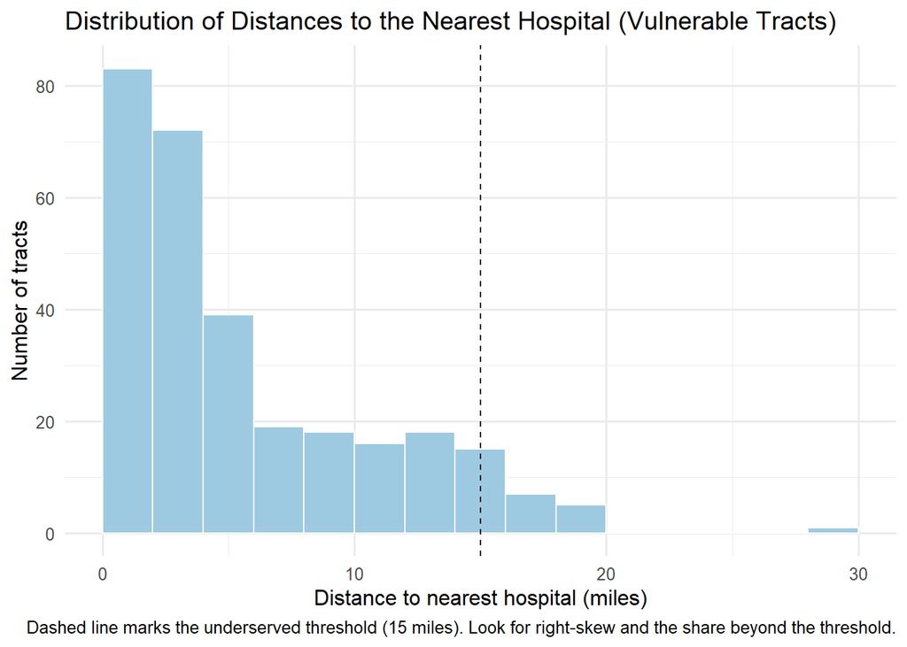

```r
p_hist
```

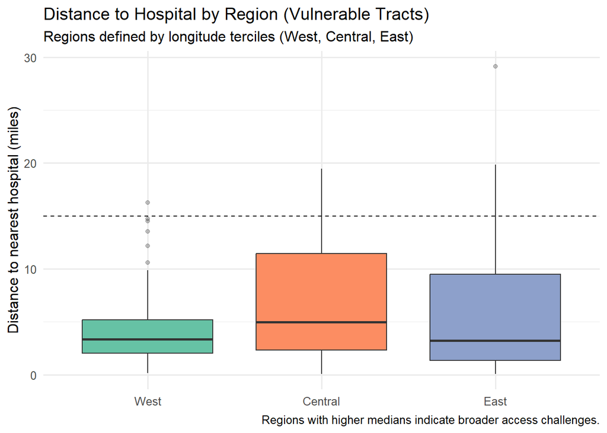

```r
p_box
```

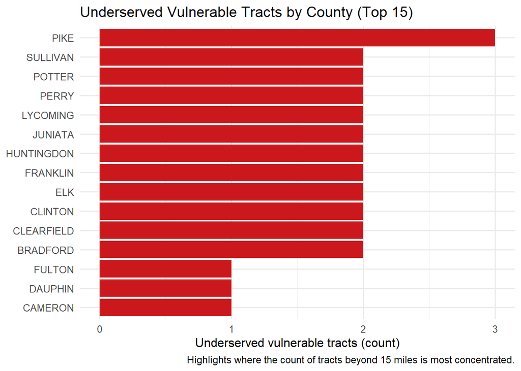

```r
p_bar
```

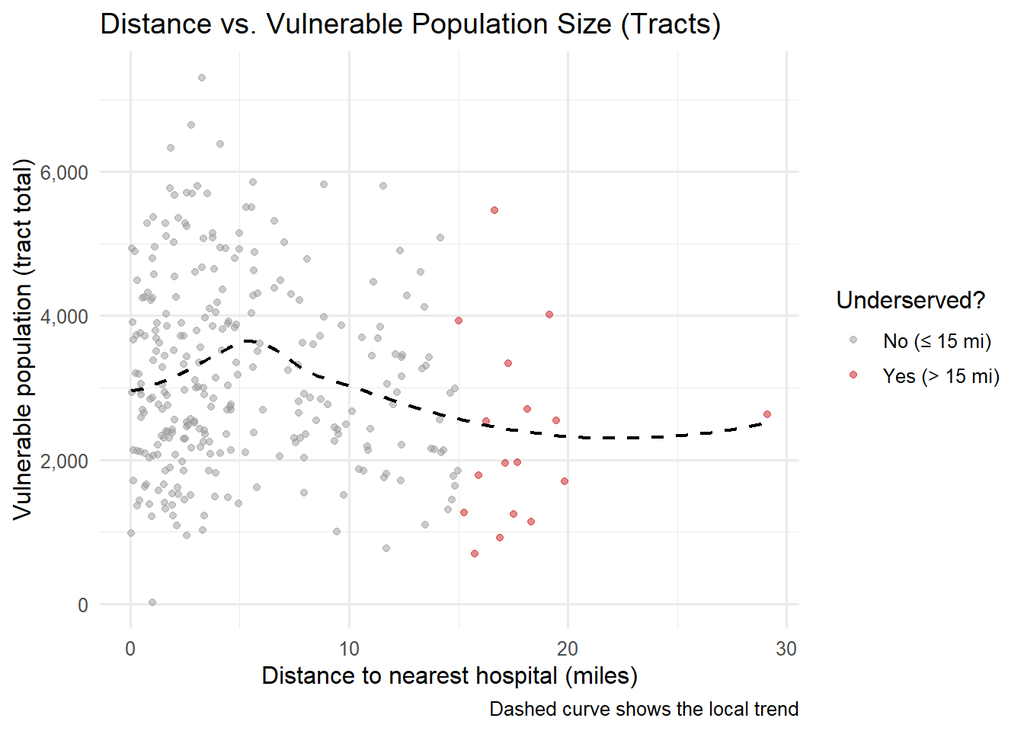

```r
p_scatter
```

**Suggested chart types:** - Histogram or density plot of distances - Box plot comparing distances across regions - Bar chart of underserved tracts by county - Scatter plot of distance vs. vulnerable population size

**Requirements:** - Clear axes labels with units - Appropriate title - Professional formatting - Brief interpretation (1-2 sentences as a caption or in text)

## Part 3: Bring Your Own Data Analysis

Choose your own additional spatial dataset and conduct a supplementary analysis.

### Challenge Options

Choose ONE of the following challenge exercises, or propose your own research question using OpenDataPhilly data (https://opendataphilly.org/datasets/).

**Note these are just loose suggestions to spark ideas - follow or make your own as the data permits and as your ideas evolve. This analysis should include bringing in your own dataset, ensuring the projection/CRS of your layers align and are appropriate for the analysis (not lat/long or geodetic coordinate systems). The analysis portion should include some combination of spatial and attribute operations to answer a relatively straightforward question**

#### Education & Youth Services

**Option A: Educational Desert Analysis**

- **Data:** Schools, Libraries, Recreation Centers, Census tracts (child population)
- **Question:** “Which neighborhoods lack adequate educational infrastructure for children?”
- **Operations:** Buffer schools/libraries (0.5 mile walking distance), identify coverage gaps, overlay with child population density
- **Policy relevance:** School district planning, library placement, after-school program siting

**Option B: School Safety Zones**

- **Data:** Schools, Crime Incidents, Bike Network
- **Question:** “Are school zones safe for walking/biking, or are they crime hotspots?”
- **Operations:** Buffer schools (1000ft safety zone), spatial join with crime incidents, assess bike infrastructure coverage
- **Policy relevance:** Safe Routes to School programs, crossing guard placement

#### Environmental Justice

**Option C: Green Space Equity**

- **Data:** Parks, Street Trees, Census tracts (race/income demographics)
- **Question:** “Do low-income and minority neighborhoods have equitable access to green space?”
- **Operations:** Buffer parks (10-minute walk = 0.5 mile), calculate tree canopy or park acreage per capita, compare by demographics
- **Policy relevance:** Climate resilience, environmental justice, urban forestry investment

#### Public Safety & Justice

**Option D: Crime & Community Resources**

- **Data:** Crime Incidents, Recreation Centers, Libraries, Street Lights
- **Question:** “Are high-crime areas underserved by community resources?”
- **Operations:** Aggregate crime counts to census tracts or neighborhoods, count community resources per area, spatial correlation analysis
- **Policy relevance:** Community investment, violence prevention strategies

#### Infrastructure & Services

**Option E: Polling Place Accessibility**

- **Data:** Polling Places, SEPTA stops, Census tracts (elderly population, disability rates)
- **Question:** “Are polling places accessible for elderly and disabled voters?”
- **Operations:** Buffer polling places and transit stops, identify vulnerable populations, find areas lacking access
- **Policy relevance:** Voting rights, election infrastructure, ADA compliance

#### Health & Wellness

**Option F: Recreation & Population Health**

- **Data:** Recreation Centers, Playgrounds, Parks, Census tracts (demographics)
- **Question:** “Is lack of recreation access associated with vulnerable populations?”
- **Operations:** Calculate recreation facilities per capita by neighborhood, buffer facilities for walking access, overlay with demographic indicators
- **Policy relevance:** Public health investment, recreation programming, obesity prevention

#### Emergency Services

**Option G: EMS Response Coverage**

- **Data:** Fire Stations, EMS stations, Population density, High-rise buildings
- **Question:** “Are population-dense areas adequately covered by emergency services?”
- **Operations:** Create service area buffers (5-minute drive = ~2 miles), assess population coverage, identify gaps in high-density areas
- **Policy relevance:** Emergency preparedness, station siting decisions

#### Arts & Culture

**Option H: Cultural Asset Distribution**

- **Data:** Public Art, Museums, Historic sites/markers, Neighborhoods
- **Question:** “Do all neighborhoods have equitable access to cultural amenities?”
- **Operations:** Count cultural assets per neighborhood, normalize by population, compare distribution across demographic groups
- **Policy relevance:** Cultural equity, tourism, quality of life, neighborhood identity

### Data Sources

**OpenDataPhilly:** https://opendataphilly.org/datasets/ - Most datasets available as GeoJSON, Shapefile, or CSV with coordinates - Always check the Metadata for a data dictionary of the fields.

**Additional Sources:**

- **Pennsylvania Open Data:** https://data.pa.gov/
- **Census Bureau (via tidycensus):** Demographics, economic indicators, commute patterns
- **TIGER/Line (via tigris):** Geographic boundaries

### Recommended Starting Points

**If you’re feeling confident:** Choose an advanced challenge with multiple data layers. **If you are a beginner, choose something more manageable that helps you understand the basics**

**If you have a different idea:** Propose your own question! Just make sure:

- You can access the spatial data
- You can perform at least 2 spatial operations

### Your Analysis

**My Chosen Question: School Access and School Choice in City of Philadelphia**

- **Data**: Schools, Census Tracts (race/income demographics)
  - School Parcels: https://opendataphilly.org/datasets/schools-parcels/ – parcel location of schools in the City of Philadelphia with attribute information for address, grade level, type, and status
  - Schools: https://opendataphilly.org/datasets/schools/ – points identifying public schools, charter schools, many private schools, school annexes, and athletic fields and facilities
- **Question:** “Is lack of school access associated with vulnerable populations?”
- **Operations:**
  - Clean datasets
  - Distance to nearest school
  - Buffer schools (10-minute walk = 0.5 mile)
  - Compare types and enrollment of schools by demographics

**Your Task:**

1. **Find and load additional data**
   - Document your data source
   - Check and standardize the CRS
   - Provide basic summary statistics

```r
# Load your additional dataset
phl_schools <- st_read("data/parcels.geojson")
phl_school_points <- st_read("data/points.geojson")
```

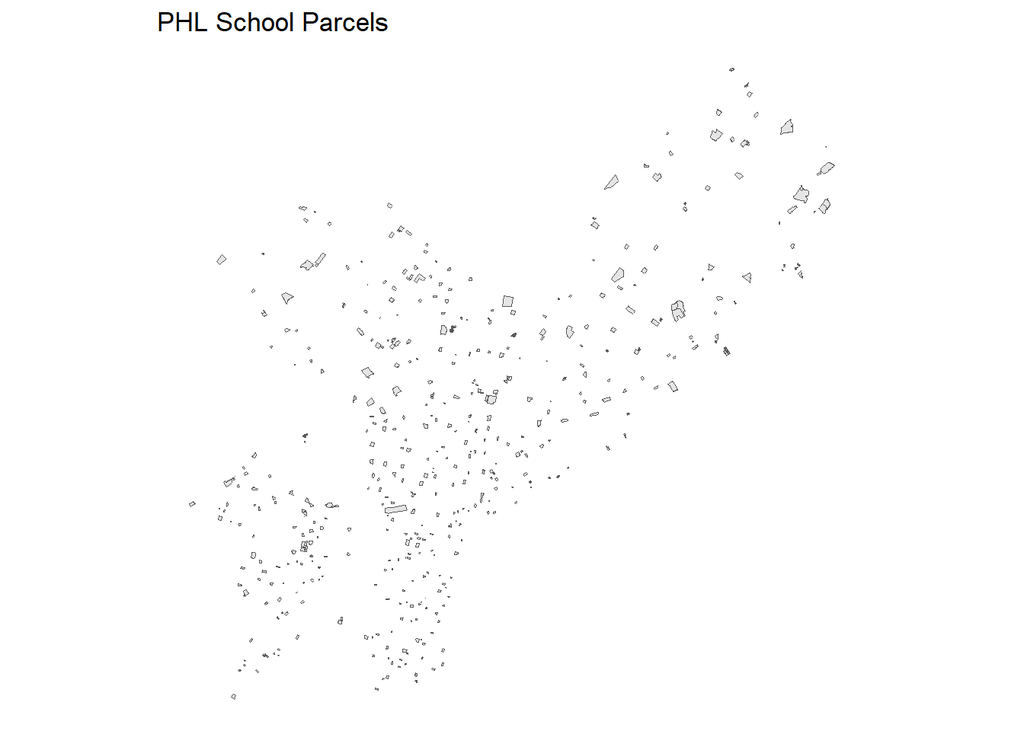

```r
#Standardize CRS
phl_schools <- st_transform(phl_schools, st_crs(pa_counties))
phl_school_points <- st_transform(phl_school_points, st_crs(pa_counties))

ggplot(phl_schools) +
  geom_sf() +
  labs(title = "PHL School Parcels") +
  theme_void()
```

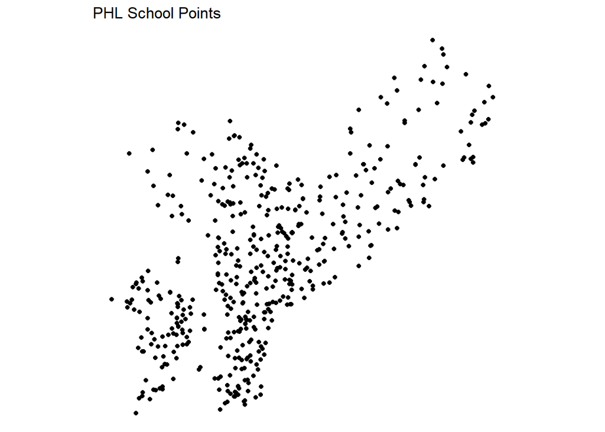

```r
ggplot(phl_school_points) +
  geom_sf() +
  labs(title = "PHL School Points") +
  theme_void()
```

**Questions to answer:**

```r
# Helper Variables for Summing Population Values for Children aged 5-19
child_pop = c("B01001_004", "B01001_005", "B01001_006", "B01001_007",
                "B01001_028", "B01001_029", "B01001_030", "B01001_031")

# Get tract-level demographic data from 2022 ACS 5-Yr Estimates for Philadelphia
phl_data <- get_acs(
  geography = "tract",
  variables = c(
    total_pop = "B01003_001",
    child_pop = child_pop,
    median_income = "B19013_001",
    poverty = "B17001_001",
    White     = "B03002_003",
    Black     = "B03002_004",
    Hispanic  = "B03002_012"
  ),
  state = "PA",
  county = "Philadelphia",
  year = 2022,
  survey = "acs5",
  output = "wide",
  geometry = TRUE
)

# Clean the county names to remove state name and "County"
phl_clean <- phl_data |>
  separate(
    NAME,
    into = c("tract_name", "county_name", "state_name"),
    sep = "; "
  ) |>
  mutate(
    tract_name = str_remove(tract_name, "Census Tract "),
    county_name = str_remove(county_name, " County")
  )
phl_clean
```

```r
# Summarize Raw Data
phl_summary <- phl_clean |>
  mutate(
    child_popE = rowSums(across(matches("^child_pop\\d+E$")), na.rm = TRUE),
    child_popM = sqrt(rowSums(across(matches("^child_pop\\d+M$"))^2, na.rm =
                                  TRUE)),
    pct_child = round((child_popE/total_popE) * 100, 2),
    pct_poverty = round((povertyE/total_popE) * 100, 2),
    pct_white = round((WhiteE/total_popE) * 100, 2),
    pct_black = round((BlackE/total_popE) * 100, 2),
    pct_hispanic = round((HispanicE/total_popE) * 100, 2)
  ) |>
  select(GEOID, tract_name, median_incomeE, median_incomeM, total_popE, total_popM,
         child_popE, child_popM, pct_child, pct_poverty,
         pct_white, pct_black, pct_hispanic)
head(phl_summary)
```

```
Simple feature collection with 6 features and 13 fields
Geometry type: MULTIPOLYGON
Dimension:     XY
Bounding box:  xmin: -75.24686 ymin: 39.91545 xmax: -75.15233 ymax: 39.94983
Geodetic CRS:  NAD83
        GEOID tract_name median_incomeE median_incomeM total_popE total_popM
1 42101001500         15         110859          24975       3251        677
2 42101001800         18         114063          30714       3300        369
3 42101002802      28.02          78871          20396       5720        796
4 42101004001      40.01          61583          22293       4029        437
5 42101006300         63          32347           4840       4415        853
6 42101007700         77          48581          13812       1815        210
  child_popE child_popM pct_child pct_poverty pct_white pct_black pct_hispanic
1        478   172.0785     14.70       99.63     66.29     18.39         4.77
2        271   102.5378      8.21      100.00     73.27     10.52         3.88
3        408   160.7420      7.13       99.83     60.70      3.11        13.27
4        420   176.4171     10.42      100.00     71.93      3.47         9.61
5        948   289.8327     21.47       99.89      4.12     81.36         7.38
6        519   123.4220     28.60       65.18     53.66     20.06         5.34
                        geometry
1 MULTIPOLYGON (((-75.16558 3...
2 MULTIPOLYGON (((-75.1662 39...
3 MULTIPOLYGON (((-75.16735 3...
4 MULTIPOLYGON (((-75.17002 3...
5 MULTIPOLYGON (((-75.24686 3...
6 MULTIPOLYGON (((-75.21292 3...
```

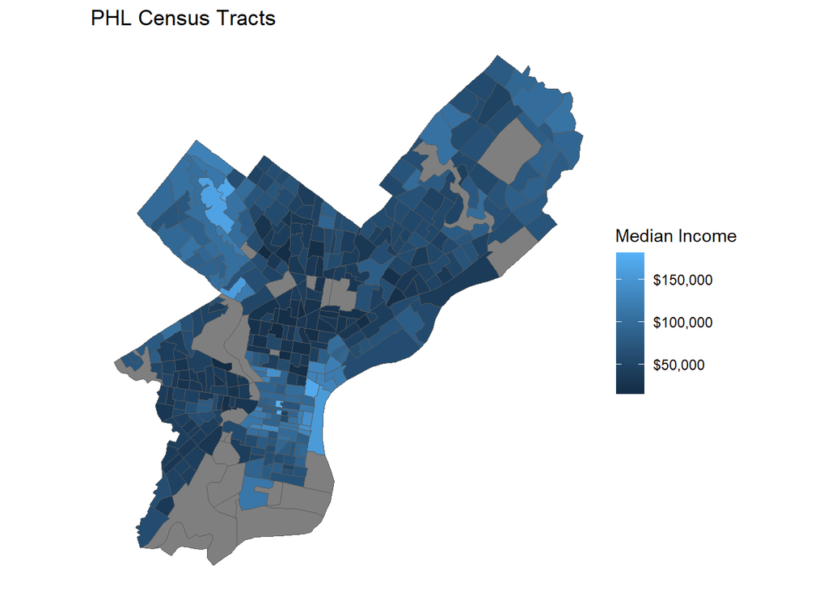

```r
# Map to confirm
phl_summary <- st_transform(phl_summary, st_crs(pa_counties))

ggplot(phl_summary) +
  geom_sf(aes(fill = median_incomeE), linewidth = 0) +
  scale_fill_continuous(labels = label_dollar()) +
  labs(
    title = "PHL Census Tracts",
    fill = "Median Income") +
  theme_void()
```

Note: Philadelphia has 408 census tracts, but as the map above visualizes, some of these census tracts have missing/incomplete data. Hence, the next part of this analysis will only use the 383 census tracts that do not have missing/NaN values

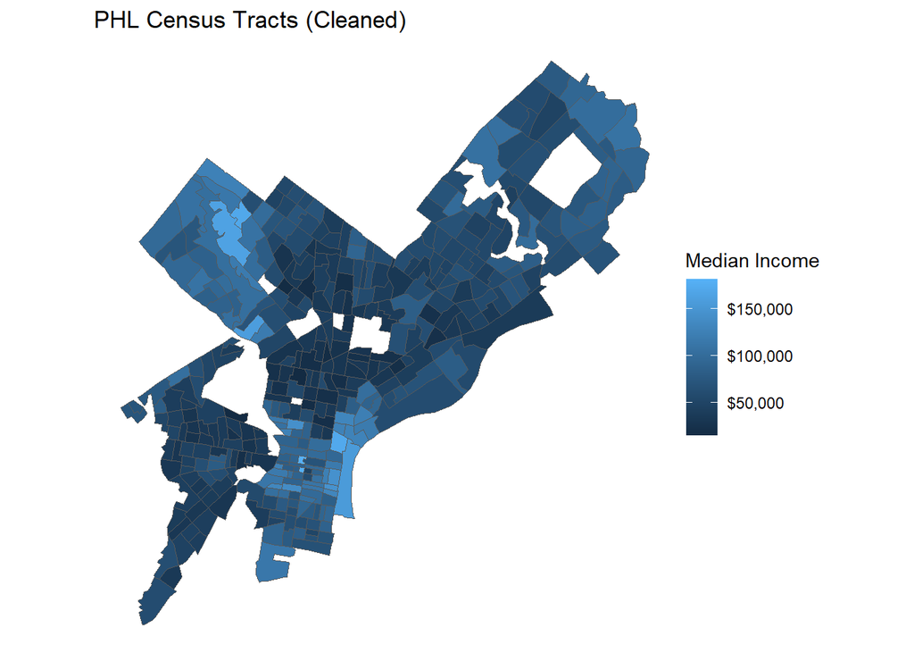

```r
phl_summary_clean <- phl_summary |>
  # Drop rows with NA/NaN in any estimate column (keeps rows even if MOE is NA)
  filter(!if_any(ends_with("E"), ~ is.na(.) | is.nan(.)))

ggplot(phl_summary_clean) +
  geom_sf(aes(fill = median_incomeE), linewidth = 0) +
  scale_fill_continuous(labels = label_dollar()) +
  labs(
    title = "PHL Census Tracts (Cleaned)",
    fill = "Median Income") +
  theme_void()
```

2. **Pose a research question**

Write a clear research statement that your analysis will answer.

**My Research Question: Is lack of school access associated with vulnerable populations?**

**Examples:**

- “Do vulnerable tracts have adequate public transit access to hospitals?”
- Are EMS stations appropriately located near vulnerable populations?”
- “Do areas with low vehicle access have worse hospital access?”
3. **Conduct spatial analysis**

Use at least TWO spatial operations to answer your research question.

**Required operations (choose 2+):**

- Buffers / Intersections / Unions / Distance Calculations
- Spatial joins
- Spatial filtering with predicates
- Point-in-polygon aggregation

**Your Task:**

```r
# Calculate the Distance from each Census tract to the nearest School
centroids <- st_centroid(phl_summary_clean, of_largest_polygon = TRUE)
nn_idx    <- st_nearest_feature(centroids, phl_school_points)
dist_m    <- st_distance(centroids, phl_school_points[nn_idx, ], by_element = TRUE)

phl_summary_clean$dist_sch_mi <- set_units(dist_m, "mi") |> drop_units()

phl_summary_clean |>
  st_drop_geometry() |>
  select(GEOID, tract_name, dist_sch_mi, pct_child, pct_poverty) |>
  arrange(desc(dist_sch_mi)) |>
  head(20)
```

```
         GEOID tract_name dist_sch_mi pct_child pct_poverty
1  42101005400         54   1.8638611     25.82      100.00
2  42101034600        346   1.1450621     13.89      100.00
3  42101036100        361   0.9349944     15.79      100.00
4  42101034802     348.02   0.8728954     22.99      100.00
5  42101035100        351   0.8714327      6.83       96.73
6  42101035702     357.02   0.8627104     14.45      100.00
7  42101005600         56   0.8353058     10.28      100.00
8  42101033300        333   0.8318995     10.67       85.23
9  42101012203     122.03   0.7763958      5.96      100.00
10 42101036502     365.02   0.7215613     20.96      100.00
11 42101033900        339   0.7099034     20.58      100.00
12 42101980100       9801   0.6841426     17.59      100.00
13 42101023500        235   0.6826007      9.16      100.00
14 42101034803     348.03   0.6735394     11.88      100.00
15 42101002000         20   0.6723388      3.80       99.61
16 42101030700        307   0.6706962     13.22      100.00
17 42101035800        358   0.6658125     18.47       99.25
18 42101021800        218   0.6525663      7.46      100.00
19 42101036301     363.01   0.6414513     18.12       99.68
20 42101012000        120   0.6355741     23.37       73.03
```

Note: From this initial exploration, there is no clear linear relationship between the distance to the nearest school and the poverty percentage of a census tract. Instead, it might be useful to first identify underserved tracts that are more than 0.5 miles (i.e. a 10-minute walking distance) from the nearest school.

**Identify Underserved Tracts**

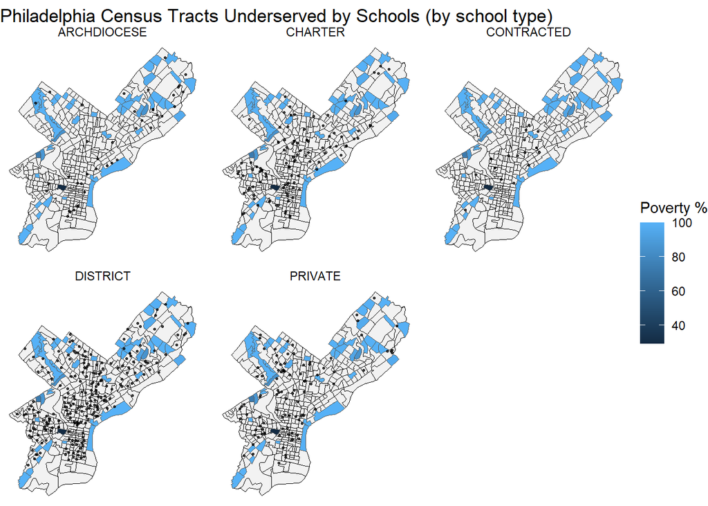

```r
underserved_threshold <- 0.5
phl_underserved <- phl_summary_clean |>
  filter(dist_sch_mi > underserved_threshold)

phl_underserved_table <- phl_underserved |>
  st_drop_geometry() |>
  select(GEOID, tract_name, dist_sch_mi, pct_child, pct_poverty) |>
  arrange(desc(dist_sch_mi))

# Map Visualization by School Type
ggplot() +
  geom_sf(data = phl_summary, fill = "gray95", color = "black", linewidth = 0.1, inherit.aes = FALSE) +
  geom_sf(data = phl_underserved, aes(fill = pct_poverty)) +
  geom_sf(data = phl_school_points, color = "black", size = 0.5, alpha = 0.75) +
  facet_wrap(~type_specific) +
  scale_fill_continuous() +
  labs(
    title = "Philadelphia Census Tracts Underserved by Schools (by school type)",
    fill = "Poverty %") +
  theme_void()
```

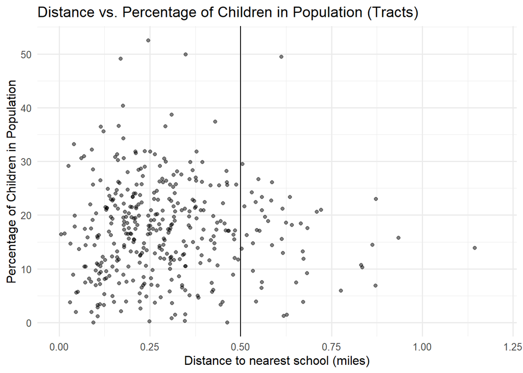

```r
# Scatter Plot: distance vs. percentage of children (per tract)
phl_sch_scatter <- ggplot(phl_summary_clean,
                    aes(x = dist_sch_mi,
                        y = pct_child,
                        )) +
  geom_point(alpha = 0.5) +
  coord_cartesian(xlim = c(0, 1.2)) +
  geom_vline(xintercept = 0.5) +
  labs(
    title   = "Distance vs. Percentage of Children in Population (Tracts)",
    x       = "Distance to nearest school (miles)",
    y       = "Percentage of Children in Population",
  ) +
  theme_minimal(base_size = 12)
phl_sch_scatter
```

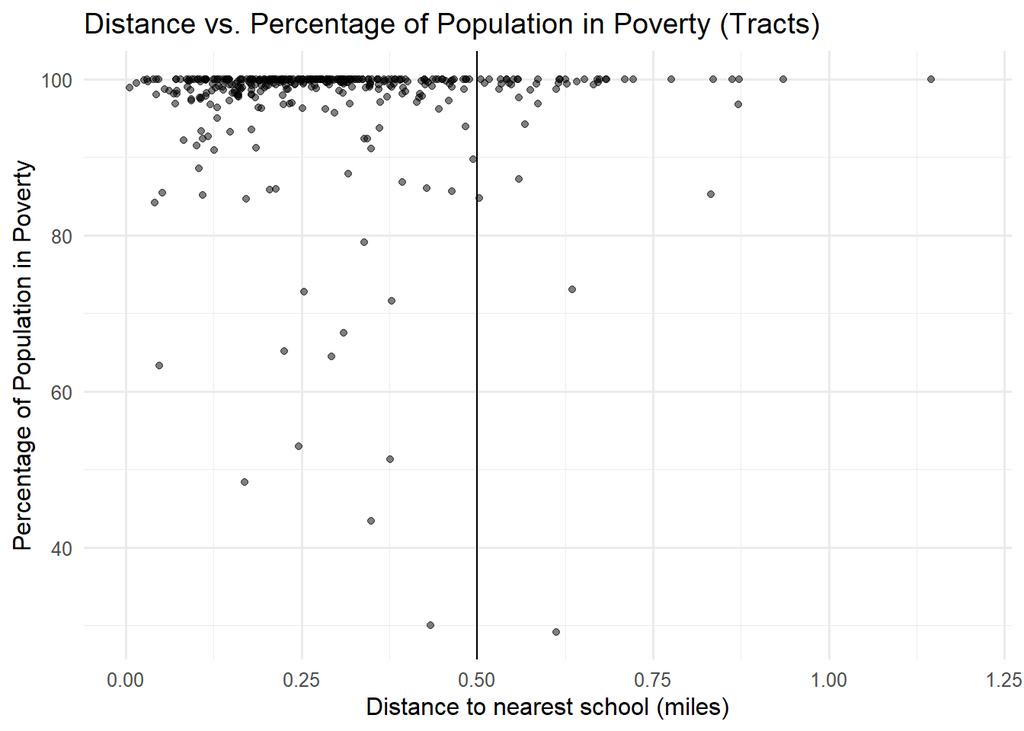

```r
# Scatter Plot: distance vs. poverty percentage (per tract)
phl_poverty_sch_scatter <- ggplot(phl_summary_clean,
                    aes(x = dist_sch_mi,
                        y = pct_poverty,
                        )) +
  geom_point(alpha = 0.5) +
  coord_cartesian(xlim = c(0, 1.2)) +
  geom_vline(xintercept = 0.5) +
  labs(
    title   = "Distance vs. Percentage of Population in Poverty (Tracts)",
    x       = "Distance to nearest school (miles)",
    y       = "Percentage of Population in Poverty",
  ) +
  theme_minimal(base_size = 12)
phl_poverty_sch_scatter
```

As shown in the scatter plots above, there is no single clear relationship between the distance to the nearest school and the percentage of children or the level of poverty in a census tract. However, we can still do some explanatory analysis to further classify schools by their average attendance levels.

```r
# Load School Attendance Data
attendance <- read_csv("data/SDP_Student_ADA_School_20241127.csv")
head(attendance)
```

```
# A tibble: 6 × 5
  `School Year` Sector   `ULCS Code` `School Name`        Average Daily Attend…¹
  <chr>         <chr>          <dbl> <chr>                                 <dbl>
1 2023-2024     District        1010 John Bartram High S…                   79.1
2 2023-2024     District        1020 West Philadelphia H…                   81.6
3 2023-2024     District        1030 High School of the …                   83.6
4 2023-2024     District        1050 Paul Robeson High S…                   89.7
5 2023-2024     District        1100 William L. Sayre Hi…                   83.2
6 2023-2024     District        1130 William T. Tilden S…                   90.9
# ℹ abbreviated name: ¹`Average Daily Attendance (YTD)`
```

```r
# Filter School Attendance Data
attendance_clean <- attendance |>
  rename(
    sch_yr = `School Year`,
    sch_name = `School Name`,
    attendance = `Average Daily Attendance (YTD)`
  ) |>
  filter(sch_yr == "2022-2023") |>
  select (sch_yr, sch_name, attendance) |>
  mutate(
    attendance_type = case_when(
      attendance < 80        ~ "Low",
      attendance <= 90       ~ "Medium",
      attendance > 90        ~ "High"),
    attendance_type = factor(attendance_type,
                            levels = c("Low", "Medium", "High"),
                            ordered = TRUE)
  )
head(attendance_clean)
```

```
# A tibble: 6 × 4
  sch_yr    sch_name                                  attendance attendance_type
  <chr>     <chr>                                          <dbl> <ord>
1 2022-2023 John Bartram High School                        77.3 Low
2 2022-2023 West Philadelphia High School                   80.3 Medium
3 2022-2023 High School of the Future                       84.5 Medium
4 2022-2023 Paul Robeson High School for Human Servi…       91.5 High
5 2022-2023 William L. Sayre High School                    82.5 Medium
6 2022-2023 William T. Tilden School                        92.2 High
```

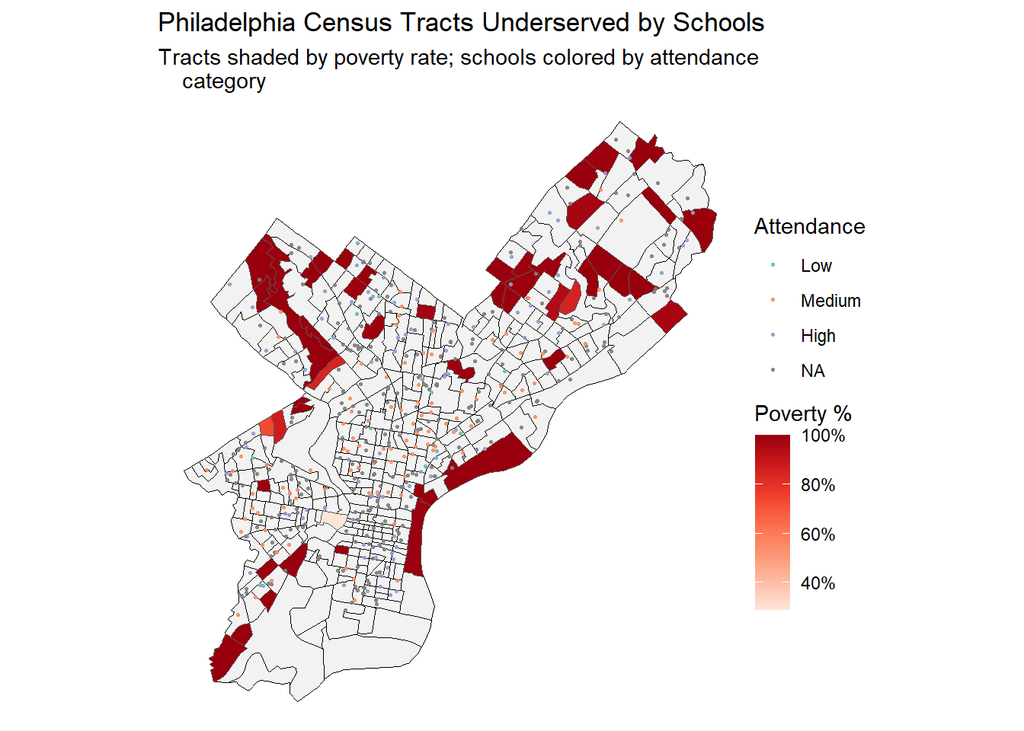

```r
# Spatial Join Attendance to School Locations
phl_school_points_clean <- phl_school_points |>
  mutate(sch_name = str_squish(str_to_lower(school_name_label)))

attendance_clean <- attendance_clean |>
  mutate(sch_name = str_squish(str_to_lower(sch_name)))

phl_school_points_attendance <- phl_school_points_clean |>
  left_join(attendance_clean |>  select(sch_name, attendance, attendance_type), by = "sch_name")

# Map Visualization
ggplot() +
  geom_sf(data = phl_summary, fill = "gray95", color = "black", linewidth = 0.1, inherit.aes = FALSE) +
  geom_sf(data = phl_underserved, aes(fill = pct_poverty)) +
  geom_sf(data = phl_school_points_attendance, aes(color = attendance_type), size = 0.5, alpha = 0.9) +
 scale_fill_distiller(
  name = "Poverty %",
  palette = "Reds",
  direction = 1,
  na.value = "grey90",
  labels = scales::label_number(accuracy = 1, suffix = "%")
  ) +
  scale_color_brewer(name = "Attendance", palette = "Set2", na.value = "grey50") +
  labs(
    title = "Philadelphia Census Tracts Underserved by Schools",
    subtitle = "Tracts shaded by poverty rate; schools colored by attendance
    category",
    fill = "Poverty %") +
  theme_void()
```

**Analysis requirements:**

- Clear code comments explaining each step
- Appropriate CRS transformations
- Summary statistics or counts
- At least one map showing your findings
- Brief interpretation of results (3-5 sentences)

## Finally - A few comments about your incorporation of feedback!

Take a few moments to clean up your markdown document and then write a line or two or three about how you may have incorporated feedback that you received after your first assignment.

*TA Feedback from Lab 1:*

1. Hide the setup code block. The Census API key is not supposed to be shared publicly. I used “include = FALSE” and “results = ‘hide’” in the relevant R code chunks
2. Printing in Console instead of RMD: if you want to print something, provide a brief explanation

## Submission Requirements

**What to submit:**

1. **Rendered HTML document posted to your course portfolio** with all code, outputs, maps, and text
   - Use `embed-resources: true` in YAML so it’s a single file
   - All code should run without errors
   - All maps and charts should display correctly

**File naming:** `LastName_FirstName_Assignment2.html` and `LastName_FirstName_Assignment2.qmd`